# PaleoACES analysis review

**Snapshot of existing outputs · 2026-10-12.** Figures and CCA summaries use verified existing analysis outputs.

PaleoACES asks how observed forest composition moves relative to the composition predicted by climate, comparing modern forest resurveys with four Holocene records. This review follows the workflow, showing preparation, methods, diagnostics and manuscript figures. Scientific decisions records the adopted choices.

## Study design and inputs

Mount Rainier (MORA) and North Cascades (NOCA) share one CCA calibrated on legacy forest plots. Resurveys and dated plant-macrofossil samples are projected into that ordination. MORA’s Holocene vegetation comes from Jay Bath, Log Wallow and Reflection Pond; NOCA’s comes from Panther Potholes. MORA fire evidence comes from Sunrise, Shadow and Little Sunrise lakes, while NOCA charcoal comes from Panther Potholes. Vegetation and fire therefore have different spatial support.

The input inventory, MORA data notes, NOCA paleo notes and chronology sources identify the source materials.

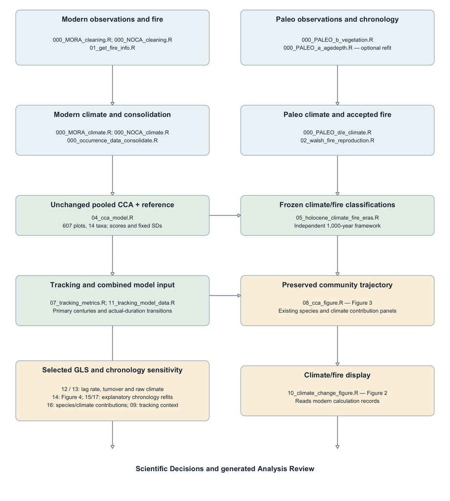

Analysis flow, associated scripts and manuscript figures

The arrows show dependencies. The table below gives the exact execution order, including figure production; figure numbers retain their manuscript meaning. The combined script contains these stages verbatim for reading. Run the workflow for an analysis rebuild.

| Execution order | Role | Script |
| --- | --- | --- |
| 1 | Preparation | 000_MORA_cleaning.R |
| 2 | Preparation | 000_NOCA_cleaning.R |
| 3 | Analysis | 01_get_fire_info.R |
| 4 | Preparation | 000_MORA_climate.R |
| 5 | Preparation | 000_NOCA_climate.R |
| 6 | Preparation | 000_PALEO_a_agedepth.R |
| 7 | Preparation | 000_PALEO_b_vegetation.R |
| 8 | Preparation | 000_FIRE_cleaning.R |
| 9 | Preparation | 000_PALEO_c_fire.R |
| 10 | Preparation | 000_PALEO_d_climate_download.R |
| 11 | Preparation | 000_PALEO_e_climate.R |
| 12 | Analysis | 02_walsh_fire_reproduction.R |
| 13 | Analysis | 03_fire_event_detection_worked_example.R |
| 14 | Preparation | 000_occurrence_data_consolidate.R |
| 15 | Analysis | 04_cca_model.R |
| 16 | Analysis | 05_holocene_climate_fire_eras.R |
| 17 | Analysis | 06_fire_method_worked_example.R |
| 18 | Analysis | 07_tracking_metrics.R |
| 19 | Analysis | 08_cca_figure.R |
| 20 | Analysis | 09_tracking_example_and_visualizations.R |
| 21 | Analysis | 10_climate_change_figure.R |
| 22 | Analysis | 11_tracking_model_data.R |
| 23 | Analysis | 12_tracking_era_models.R |
| 24 | Analysis | 13_tracking_lake_sensitivity.R |
| 25 | Analysis | 14_tracking_manuscript_figure.R |
| 26 | Analysis | 15_tracking_predictor_models.R |
| 27 | Analysis | 16_cca_transition_contributions.R |
| 28 | Analysis | 17_species_contribution_models.R |

| Prepared input | Rows | Plot/sample IDs | Taxa |
| --- | --- | --- | --- |
| MORA | 2490 | 331 | 23 |
| NOCA | 1775 | 305 | 31 |
| paleo | 9850 | 989 | 12 |
| consolidated | 13950 | 1625 | 22 |

Full cleaning summary table.

## Modern vegetation preparation

Presence means an adult **or** regeneration record. MORA uses the original legacy workbook and cleaned resurvey tree and seedling files. NOCA applies the received corrected-tree workbook before building occurrences; unsupported identification labels are discarded. Both cleaners retain matched survey plots.

**MORA’s adult resurvey date is authoritative (decision 2026-10-07).** Seedling records are assigned to their corresponding adult visit before presence is constructed. For the 13 plots visited in multiple years, only the latest adult visit and its matching seedlings are retained; visits tied within a year remain pooled. This replaces pooling across years and using the earliest tree/seedling year. The received CSVs are preserved.

The source-year comparison identifies 95 supplied plot names, including 48 analyzed pairs. That total includes `PRAC-1`, a practice plot without a standardized ID; 94 have standardized IDs. Conflicting years already occur in the original CSVs and pass unchanged through their upstream cleaner. The earlier export process is unknown. The 95-plot source table records the conflicting years, adult dates, treatment and evidence locations; survey-year notes give the rationale.

| Plot | Adult visits | Selected year | Selected date | Adult records kept | Earlier records removed |
| --- | --- | --- | --- | --- | --- |
| CHIN-084 | 2014; 2015 | 2015 | 8/27/15 | 44 | 56 |
| GOAT-468 | 2014; 2016 | 2016 | 6/30/16 | 14 | 48 |
| LONG-356 | 2015; 2016 | 2016 | 6/21/16 | 25 | 36 |
| LOWE-045 | 2015; 2016 | 2016 | 6/22/16 | 10 | 19 |
| RAMP-093 | 2015; 2016 | 2016 | 6/23/16 | 23 | 36 |
| RAMP-505 | 2018; 2019 | 2019 | 7/11/19 | 40 | 85 |
| RAMP-506 | 2018; 2019 | 2019 | 7/11/19 | 75 | 103 |
| SMO-364 | 2016; 2019 | 2019 | 8/22/19 | 47 | 55 |
| SUNS-046 | 2015; 2016 | 2016 | 6/22/16 | 10 | 22 |
| TAHO-003 | 2014; 2016 | 2016 | 6/24/16 | 21 | 18 |
| WHIT-071 | 2014; 2016 | 2016 | 6/30/16 | 22 | 66 |
| WHIT-273 | 2014; 2016 | 2016 | 6/28/16 | 82 | 121 |
| WHIT-307 | 2015; 2016 | 2016 | 6/29/16 | 20 | 33 |

Full mora repeat visits table.

NOCA excludes `BAK487` for its old clearcut, `BEAV6061` for uncertain relocation, and `CARI449`/`CARI450` for GPS problems. The latter share coordinates despite conflicting elevations, and Rachel’s notes supply no verified correction. These exclusions apply to both dates. The cleaned NOCA data contain 305 pairs; CCA eligibility is assessed later. The cleaning guide and GPS source note explain the decisions.

| Patch audit status | Affected plot IDs |
| --- | --- |
| excluded | 3 |
| included | 51 |

| Study-excluded plot | Reason |
| --- | --- |
| BAK487 | old clearcut; removed from Wilson final analysis |
| BEAV6061 | historic plot location uncertain; resurvey is an avalanche chute |
| CARI449 | GPS problem; shared coordinates conflict with elevations; no verified correction |
| CARI450 | GPS problem; shared coordinates conflict with elevations; no verified correction |

Complete correction audit, study exclusions, and excluded GPS-coordinate collision.

### Show which NOCA plots remain after cleaning

The cleaned data contain more plots than the final CCA comparisons. Plots empty at one date and the agreed plot exclusions are shown separately.

Script: 000_NOCA_cleaning.R. Complete PDF (3 pages).

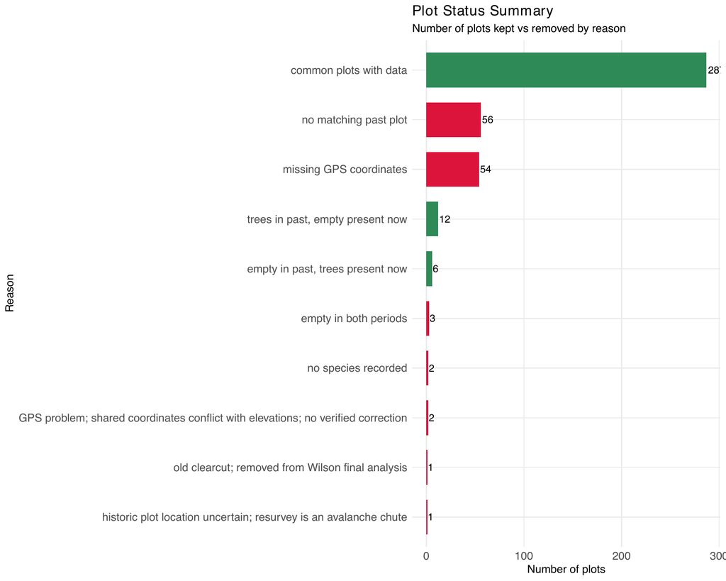

Show which NOCA plots remain after cleaning. — PDF page 1

### Show species counts before model taxon selection

Counts reflect adult-or-regeneration presence in cleaned survey plots; they do not measure abundance.

Script: 000_MORA_cleaning.R. Complete PDF (3 pages).

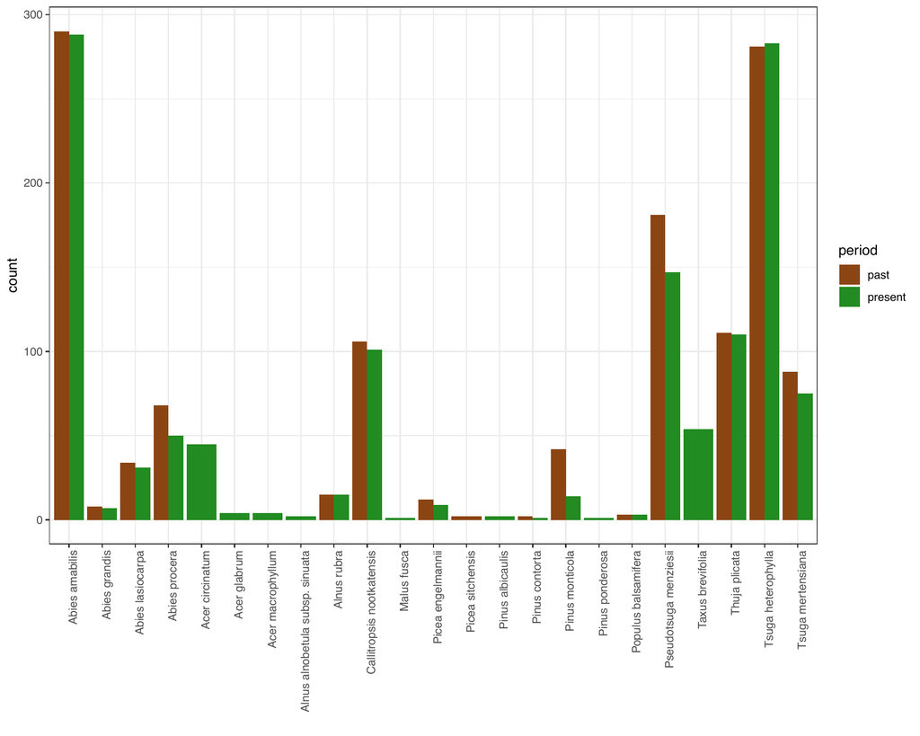

Show species counts before model taxon selection. — PDF page 3

### Compare corrected legacy and resurvey species counts

Species differences describe cleaned surveys before cross-site harmonization and the CCA threshold.

Script: 000_NOCA_cleaning.R. Complete PDF (3 pages).

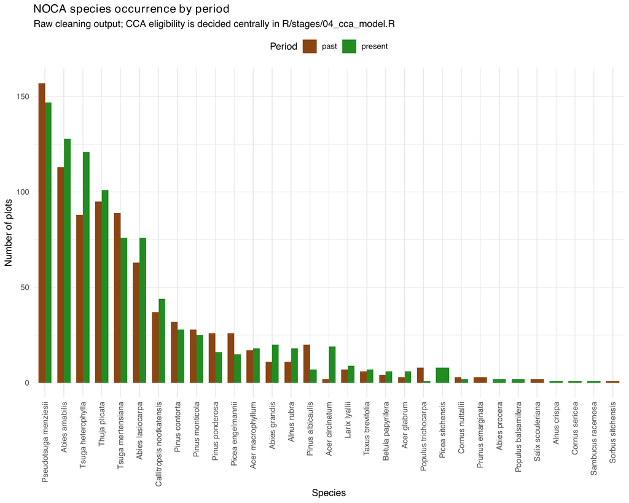

Compare corrected legacy and resurvey species counts. — PDF page 3

## Modern fire assignments

Mapped disturbance records identify fire exposure for the paired modern plots. NOCA has 32 burned and 273 unburned plots, with matching assignments on all 303 plots shared with Wilson’s reference. MORA’s mapped record covers 1987–2017, so no mapped fire does not establish that a plot remained unburned throughout the full survey interval.

### Audit NOCA modern fire assignment against Wilson reference plots

The 303 shared plots agree. The cleaned 305-plot universe excludes CARI449/CARI450 for GPS problems; the Wilson reference is not substituted for it.

Script: 01_get_fire_info.R. Complete PDF (1 page).

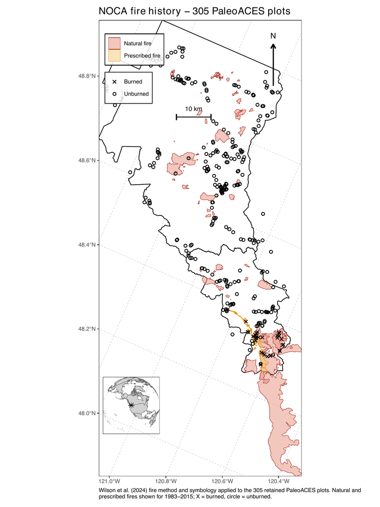

Audit NOCA modern fire assignment against Wilson reference plots. — PDF page 1

## Modern climate preparation

CHELSA V2.1 monthly values supply spring temperature (MSpT), winter temperature (MWT), summer precipitation (SP) and winter precipitation (WP). Temperature is the midpoint of monthly minima and maxima, then averaged over the season; precipitation is summed. These are seasonal climate proxies, not direct measures of growing degree days, soil moisture or snowpack.

Spring is March–May, summer June–August and winter December–February. Modern December belongs to the following winter. All three months are required; temperatures are in °C and precipitation in mm per season.

**Climate-year selection.** Historical climate remains **1979–1989** at both sites. Each modern plot uses its adult resurvey year **Y** and the five preceding years: **Y−5 through Y, inclusive**. We average these six years to represent the interannual climate dynamics that the community experienced before and during the survey. A 2014 resurvey therefore uses 2009–2014, with December 2008 included in winter 2009. Every modern constraint requires six complete season-years.

Climate rates use the interval from the historical midpoint **1984** to the plot-specific modern midpoint **Y−2.5**: **27.5–32.5 years at MORA** and **27.5–28.5 years at NOCA**. Vegetation rates use the selected adult year and legacy references of 1977.5 (MORA) or 1983 (NOCA). Missing January 1979 leaves ten complete legacy winters; spring and summer retain eleven years. The historical window choice remains settled, and possible MORA precipitation inhomogeneity remains a limitation.

| Site | Period | Plots | Spring years | Winter years | Summer years | Winter precipitation years |
| --- | --- | --- | --- | --- | --- | --- |
| MORA | past | 331 | 11 | 10 | 11 | 10 |
| MORA | present | 331 | 6 | 6 | 6 | 6 |
| NOCA | past | 305 | 11 | 10 | 11 | 10 |
| NOCA | present | 305 | 6 | 6 | 6 | 6 |

Full climate windows table.

The following cohorts and diagnostic use the final paired comparison plots. The annual lines show those same plots; separate colored bands show each cohort’s window without hiding overlapping windows. MORA is blue and NOCA orange.

| Site | Survey | Adult resurvey year | First climate year | Last climate year | Analyzed plots |
| --- | --- | --- | --- | --- | --- |
| MORA | past | — | 1979 | 1989 | 330 |
| MORA | present | 2014 | 2009 | 2014 | 50 |
| MORA | present | 2015 | 2010 | 2015 | 174 |
| MORA | present | 2016 | 2011 | 2016 | 47 |
| MORA | present | 2017 | 2012 | 2017 | 11 |
| MORA | present | 2018 | 2013 | 2018 | 7 |
| MORA | present | 2019 | 2014 | 2019 | 41 |
| NOCA | past | — | 1979 | 1989 | 277 |
| NOCA | present | 2014 | 2009 | 2014 | 50 |
| NOCA | present | 2015 | 2010 | 2015 | 227 |

Full survey climate windows table.

### Compare selected survey windows with the full 1979–2021 record

Detrending does not resolve CHELSA product continuity. Apparent precipitation anomalies remain a scientific limitation.

Script: test_survey_year_anomaly.R. Complete PDF (1 page).

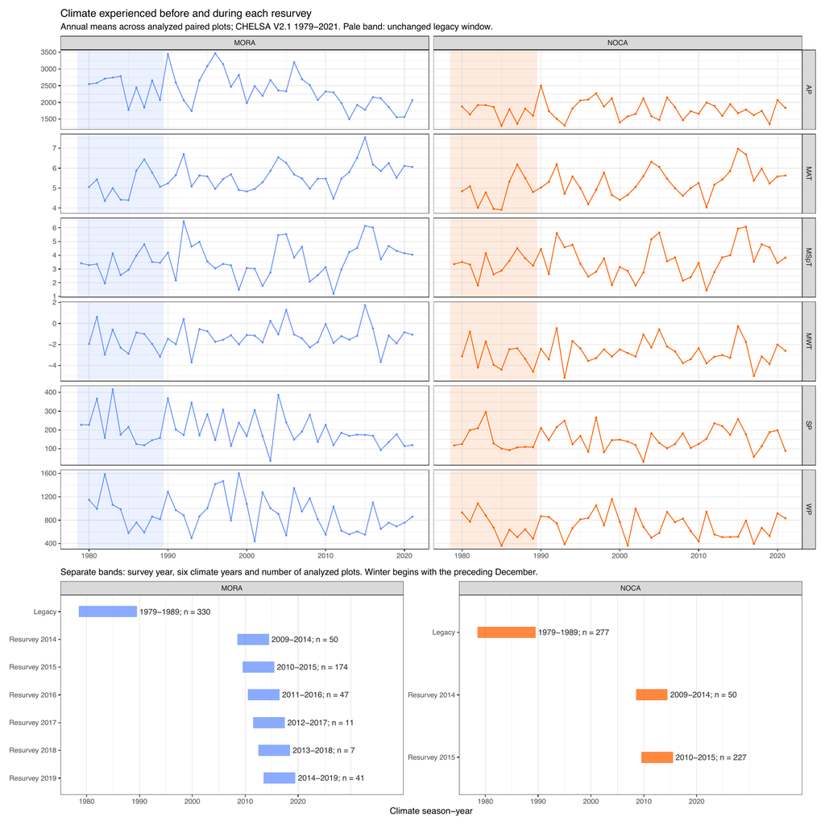

Compare selected survey windows with the full 1979–2021 record. — PDF page 1

## Chronology and uncertainty

The existing stored Bacon models are retained. Each primary original sample receives its **unrounded median age over all stored posterior rows**, not the median of a selected draw subset. Original sample identities do not depend on estimated ages.

The sensitivity uses 1,000 reproducibly selected complete posterior chronologies per lake. One selected posterior row supplies all sample and NOCA fire-event ages within that lake. No MCMC or CCA recalibration is performed. MORA regional charcoal chronologies remain fixed. Primary confidence intervals are conditional on the primary reconstruction; separate refits examine changes in coefficient direction, magnitude and statistical support.

### Inspect four fitted age-depth models and slump treatment

The four age-depth curves show sediment accumulation, removed instantaneous layers and modeled age ranges. Those ranges are conditional on the adopted controls and Bacon settings.

Script: 000_PALEO_a_agedepth.R. Complete PDF (1 page).

[figure not shown]

Inspect four fitted age-depth models and slump treatment. — PDF page 1

### Compare published activity errors with assumed ±10-year age uncertainty

The sensitivity concerns the upper 35–40 cm of Panther Potholes; uncertainty in published fire chronologies is not equivalent across sites. **Chronology sensitivity**.

Script: 000_PALEO_a_agedepth.R. Complete PDF (1 page).

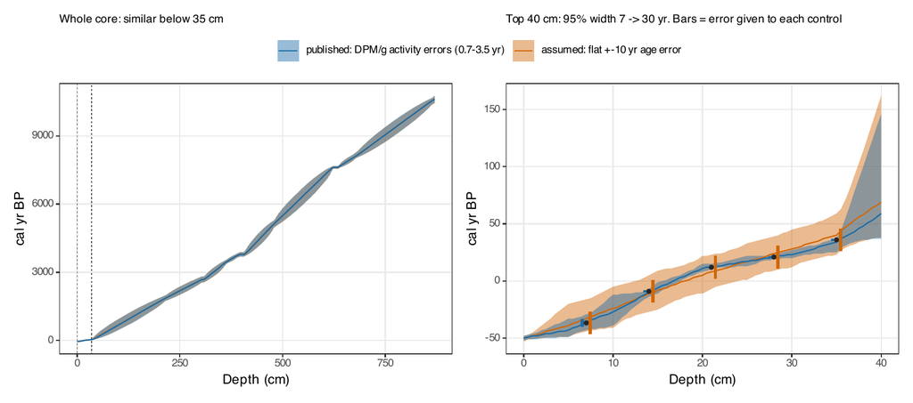

Compare published activity errors with assumed ±10-year age uncertainty. — PDF page 1

## Paleo vegetation and fire preparation

Taxonomic categories are harmonized within original samples. Separate depths and Neotoma sample IDs remain separate even when their posterior median ages coincide. Samples with no retained taxa remain in the exclusion audit and have no WA position. Accepted charcoal-event detection and its descriptive products remain unchanged. The ecological exposure uses whole vegetation-transition durations and coherent NOCA redating.

## Paleo climate preparation

CHELSA-TraCE21k supplies climate at the four pond locations. Each vegetation sample is matched to the available climate slice nearest its own age, within the 50-year tolerance. The seasonal variables and units match the modern analysis; December remains within its paleo climatology slice.

Raw TraCE21k is the current input. A V2.1-based correction is planned as a sensitivity and has not been applied. The comparison at the end of this review shows the available recent overlap and its different averaging windows.

### Inspect redundancy among candidate climate variables

Only page 2 (correlations) is inline. Page 1 and associated pace tables retain the former 500-year sensitivity and are not primary rate evidence. **Correlation diagnostic; full PDF includes 500-year sensitivity**.

Script: test_climate_change_variables.R. Complete PDF (2 pages).

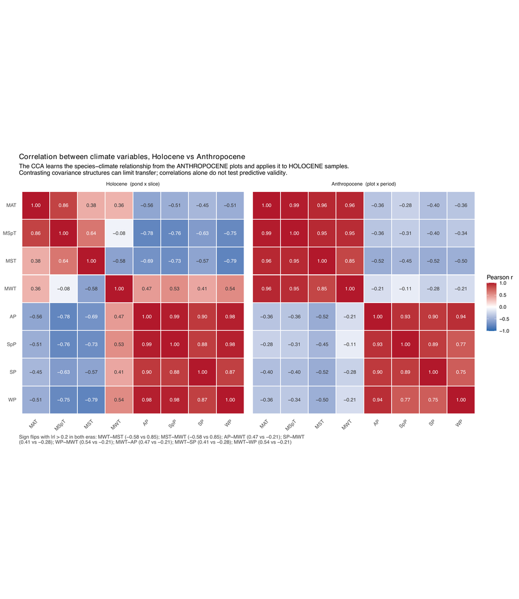

Inspect redundancy among candidate climate variables. — PDF page 2

Only the correlation page is shown here. The full climate diagnostic also contains older **500-year sensitivity** calculations; those are separate from primary climate-rate results.

## Accepted fire events

The accepted-event catalog uses the shared tapas detector with core-specific interpolation, background smoothing and local thresholds. All cores use unlogged charcoal accumulation, robust LOWESS background, a local Gaussian-mixture threshold and a 75-year count screen with p ≤ 0.05. Accepted totals are 17 Sunrise, 14 Shadow, 13 Little Sunrise and 66 Panther Potholes. The existing 12.5-year NOCA interpolation sensitivity yields 72 events.

| Lake | Engine | Interpolation years | Background years | Local threshold |
| --- | --- | --- | --- | --- |
| Sunrise Lake | tapas | 48 | 800 | 0.95 |
| Shadow Lake | tapas | 47 | 1000 | 0.95 |
| Little Sunrise Lake | tapas | 42 | 500 | 0.95 |
| PantherPotholes | tapas | 12 | 500 | 0.99 |

Full fire settings table.

| Lake | Candidates | Count rejected | Accepted |
| --- | --- | --- | --- |
| Sunrise Lake | 26 | 9 | 17 |
| Shadow Lake | 17 | 3 | 14 |
| Little Sunrise Lake | 20 | 7 | 13 |
| PantherPotholes | 66 | 0 | 66 |

Full event audit table.

The official CharAnalysis comparison is separate from the primary catalog. Its discrepancy with Walsh’s publication is retained without threshold tuning.

| Lake | Official R episodes | Published total | Difference |
| --- | --- | --- | --- |
| Little Sunrise Lake | 14 | 16 | -2 |
| Shadow Lake | 16 | 18 | -2 |
| Sunrise Lake | 15 | 24 | -9 |

Full walsh audit table.

### Compare official CharAnalysis results with published Walsh totals

The official CharAnalysis implementation and Walsh publication give different event totals. This comparison is separate from the primary tapas event catalog, whose thresholds were not tuned to force agreement.

Script: 02_walsh_fire_reproduction.R. Complete PDF (3 pages).

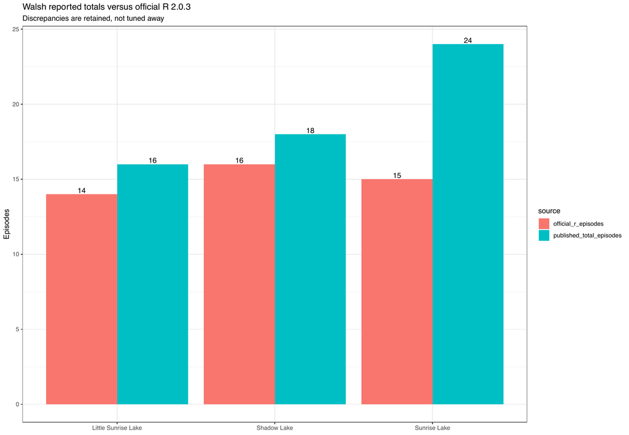

Compare official CharAnalysis results with published Walsh totals. — PDF page 3

### Compare fire-event detection in all four lake records

Each panel shows the charcoal residual, the local noise threshold (dashed), accepted events (filled circles), and peaks rejected by the minimum-count screen (red crosses). The three MORA records use 95% thresholds; Panther Potholes uses 99%. These events are used later to identify high-fire periods.

Script: 03_fire_event_detection_worked_example.R. Complete PDF (3 pages).

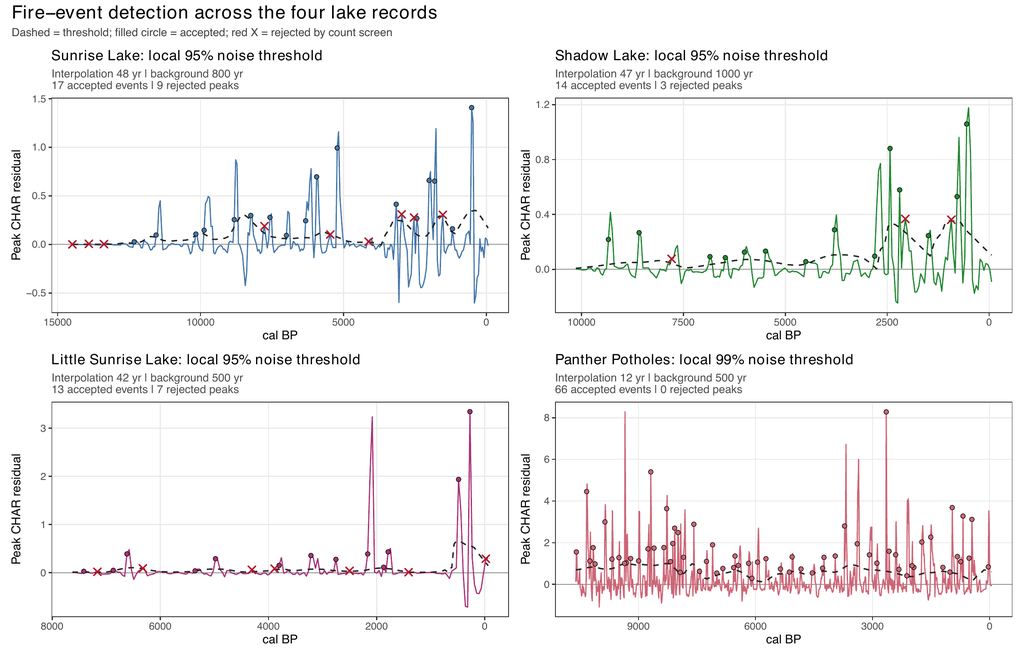

Compare fire-event detection in all four lake records. — PDF page 2

## Taxonomy and species selection

Consolidation aligns Populus, Picea and Abies identifications across surveys and macrofossils. Acer circinatum and Taxus brevifolia are removed for stratum compatibility. Pinus ponderosa’s manual exclusion was reversed on 2026-10-08; it is now retained and follows the ordinary frequency rule below.

CCA retains a taxon when it occurs in **at least 20 plots or samples in any one site × period group**. The rule does not require 20 in every group. Pinus albicaulis reaches exactly 20 and remains included. Selection rests on taxon relevance and ordination interpretation; increased explained inertia alone is not its justification. The existing selected taxa and matched-legacy calibration are frozen during this migration; new paleo identities affect projection records and diagnostics, not calibration.

| Taxon | MORA legacy | MORA resurvey | MORA paleo | NOCA legacy | NOCA resurvey | NOCA paleo | CCA retained |
| --- | --- | --- | --- | --- | --- | --- | --- |
| Abies amabilis | 290 | 288 | 119 | 113 | 128 | 0 | TRUE |
| Abies lasiocarpa | 34 | 31 | 94 | 63 | 76 | 473 | TRUE |
| Abies procera | 68 | 50 | 43 | 0 | 0 | 0 | TRUE |
| Callitropsis nootkatensis | 106 | 101 | 78 | 37 | 44 | 38 | TRUE |
| Picea engelmannii | 12 | 9 | 5 | 26 | 22 | 12 | TRUE |
| Pinus contorta | 2 | 1 | 31 | 32 | 28 | 293 | TRUE |
| Pinus monticola | 42 | 14 | 90 | 28 | 25 | 504 | TRUE |
| Pseudotsuga menziesii | 181 | 147 | 40 | 157 | 147 | 597 | TRUE |
| Tsuga heterophylla | 281 | 283 | 54 | 88 | 121 | 180 | TRUE |
| Tsuga mertensiana | 88 | 75 | 110 | 89 | 76 | 39 | TRUE |
| Abies grandis | 8 | 7 | 0 | 11 | 20 | 0 | TRUE |
| Alnus rubra | 15 | 15 | 0 | 11 | 18 | 0 | FALSE |
| Picea sitchensis | 2 | 0 | 0 | 0 | 0 | 0 | FALSE |
| Populus trichocarpa | 3 | 3 | 0 | 8 | 3 | 0 | FALSE |
| Thuja plicata | 111 | 110 | 0 | 95 | 101 | 168 | TRUE |
| Acer macrophyllum | 0 | 4 | 0 | 17 | 18 | 0 | FALSE |
| Malus fusca | 0 | 1 | 0 | 0 | 0 | 0 | FALSE |
| Pinus albicaulis | 0 | 2 | 0 | 20 | 7 | 0 | TRUE |
| Pinus ponderosa | 0 | 1 | 0 | 26 | 16 | 0 | TRUE |
| Juniperus communis | 0 | 0 | 0 | 0 | 0 | 8 | FALSE |
| Betula papyrifera | 0 | 0 | 0 | 4 | 6 | 0 | FALSE |
| Larix lyallii | 0 | 0 | 0 | 7 | 9 | 0 | FALSE |

Full CCA taxa table.

NOCA size classes differ between dates: legacy regeneration spans 0–3 m and adults exceed 3 m; resurvey seedlings span 10–140 cm and trees exceed 1.4 m. These strata are not identical measurements across surveys.

### Inspect consolidated occurrence counts in each site-period group

Retention requires at least 20 plots or samples in one group. The threshold is not required in every group.

Script: 000_occurrence_data_consolidate.R. Complete PDF (1 page).

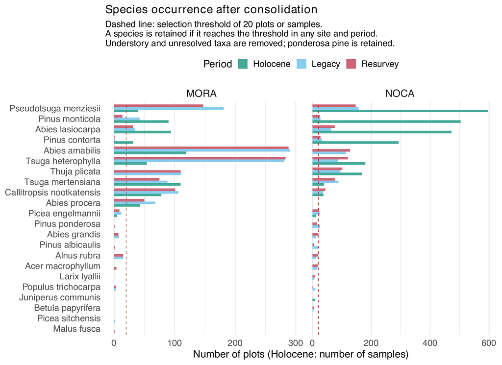

Inspect consolidated occurrence counts in each site-period group. — PDF page 1

### Expose adult versus regeneration support for presence

Adult and regeneration sources contribute to presence; stem counts and macrofossil percentages are not combined as abundance.

Script: 000_occurrence_data_consolidate.R. Complete PDF (1 page).

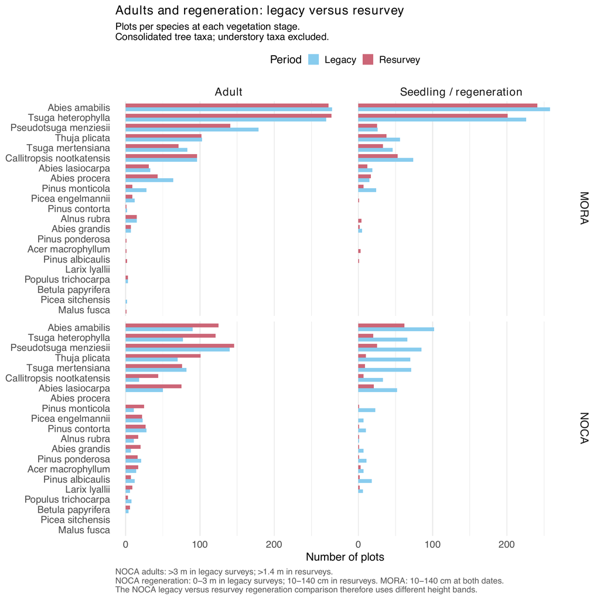

Expose adult versus regeneration support for presence. — PDF page 1

### Inspect taxon site confounding and temporal occupancy

Presence/absence occupancy in native 100-year cells using original samples and unrounded posterior median ages.

Script: test_species_through_time.R. Complete PDF (1 page).

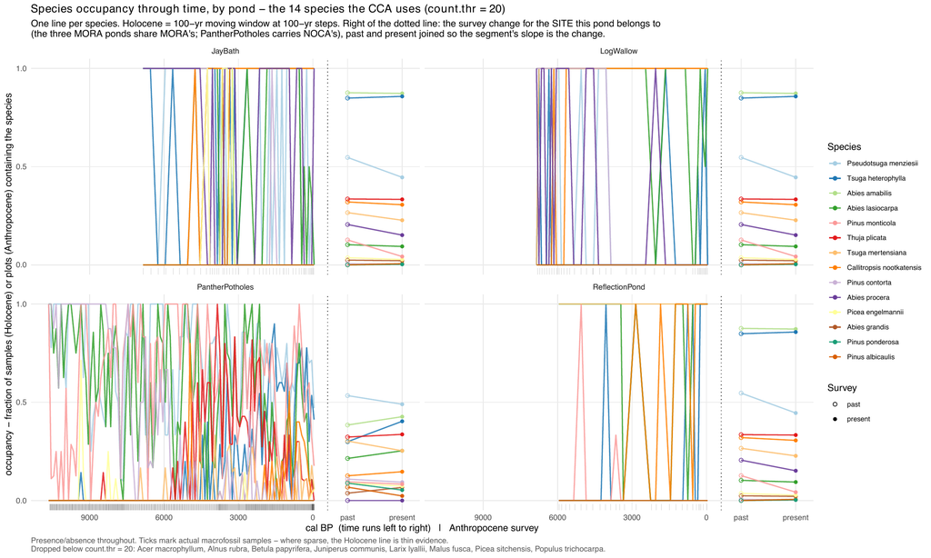

Inspect taxon site confounding and temporal occupancy. — PDF page 1

The occupancy display uses original samples placed on the native 100-year grid.

## Plots and samples included in CCA

The following diagram starts with the supplied survey lists and core sample depths. It shows losses during matching and cleaning, then the species and climate checks required for CCA. The starting legacy and resurvey counts are separate; their exclusions must not be added together. Original sample identities are retained when median ages coincide.

### From starting plots and core samples to the CCA

Each count shows plots or samples remaining. Reasons beside the arrows explain losses; repeated visits and sample depths combined at the same modeled age are distinguished from exclusions. The middle panels show legacy adult-tree areas among retained plots and the confirmed 500 m² resurvey area at both sites.

Script: plot_sample_selection.R. Complete PDF (1 page).

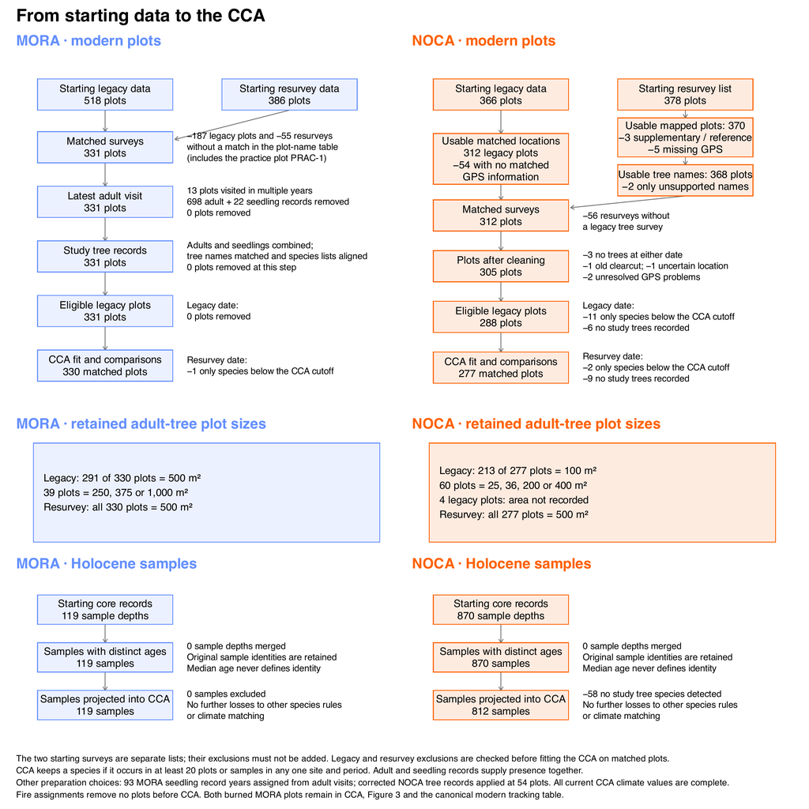

From starting plots and core samples to the CCA. — PDF page 1

The counts at each step and choices affecting records are available as tables.

The diagram also shows the legacy adult-tree plot sizes among the plots retained for CCA. Adult-tree resurvey plots cover **500 m² at both sites**. Legacy areas vary, so matching plot identities does not mean that the sampled areas were equal. Plot size currently does not determine eligibility.

Choices such as correcting tree records and keeping the latest adult visit change the observations without necessarily removing plots. They are shown alongside the count changes. All current CCA climate values are complete. The two burned MORA plots remain in CCA and in the canonical 607-plot tracking table.

04_cca_model.R resolves eligibility **before fitting or projecting**. An observation with no retained taxa has no observed WA position. It is excluded from both observed and climate-predicted comparisons. Modern endpoints use the same eligible pairs at both dates; Holocene WA and LC positions also use identical samples. The CCA is fitted on the legacy observations of these same matched plots; a plot excluded at resurvey is also excluded from calibration. The diagram’s final modern counts therefore serve both fitting and comparison.

| Era | Site | Use | Prepared plots/samples | Excluded | Included |
| --- | --- | --- | --- | --- | --- |
| anthropocene | MORA | Legacy calibration | 331 | 1 | 330 |
| anthropocene | MORA | Modern paired comparison | 331 | 1 | 330 |
| anthropocene | NOCA | Legacy calibration | 305 | 28 | 277 |
| anthropocene | NOCA | Modern paired comparison | 305 | 28 | 277 |
| holocene | MORA | Paleo projection | 119 | 0 | 119 |
| holocene | NOCA | Paleo projection | 870 | 58 | 812 |

Full CCA eligibility counts table.

Exclusion reasons are separated below. Each modern pair is counted once, against its first failing endpoint, with legacy checked first. Calibration and paired-comparison counts overlap and must not be added together. Holocene counts are samples before age draws or temporal binning.

| Era | Site | Use | Excluded at | Reason | Count |
| --- | --- | --- | --- | --- | --- |
| anthropocene | MORA | Legacy calibration | present | Only taxa excluded by CCA species selection | 1 |
| anthropocene | MORA | Modern paired comparison | present | Only taxa excluded by CCA species selection | 1 |
| anthropocene | NOCA | Legacy calibration | past | No tree taxa recorded at legacy | 6 |
| anthropocene | NOCA | Legacy calibration | past | Only taxa excluded by CCA species selection | 11 |
| anthropocene | NOCA | Legacy calibration | present | Loss of all recorded tree-taxon presence at resurvey | 9 |
| anthropocene | NOCA | Legacy calibration | present | Only taxa excluded by CCA species selection | 2 |
| anthropocene | NOCA | Modern paired comparison | past | No tree taxa recorded at legacy | 6 |
| anthropocene | NOCA | Modern paired comparison | past | Only taxa excluded by CCA species selection | 11 |
| anthropocene | NOCA | Modern paired comparison | present | Loss of all recorded tree-taxon presence at resurvey | 9 |
| anthropocene | NOCA | Modern paired comparison | present | Only taxa excluded by CCA species selection | 2 |
| holocene | NOCA | Paleo projection | paleo | No tree taxa detected in paleo sample | 58 |

Full CCA exclusion summary table.

“Loss of all recorded tree-taxon presence at resurvey” describes absence in the sampled taxa and strata, not proven biological extinction. “No tree taxa detected in paleo sample” describes macrofossil non-detection. Cases holding only taxa removed during consolidation or CCA selection are listed separately. Missing climate and unmatched endpoints are also classified if encountered.

The sample table and paired-plot table retain the individual reasons. The cleaned data retain these observations even when they cannot enter CCA tracking.

## Holocene sampling support on native climate intervals

The pre-CCA diagnostic places every original macrofossil sample once at its unrounded full-posterior median Bacon age, including samples subsequently excluded from WA projection. Macrofossil lakes remain distinguished with the same MORA/NOCA count scale. Fire panels show accepted-event totals by park; MORA regional cores are combined, not plotted as separate vegetation lakes. Covered zero-event cells remain zero and missing coverage breaks the line. These descriptive counts use native climate intervals and are not transition-model observations.

### Inspect macrofossil sampling and accepted fire detections on native 100-year climate cells before CCA

Script: 000_occurrence_data_consolidate.R. Complete PDF (1 page).

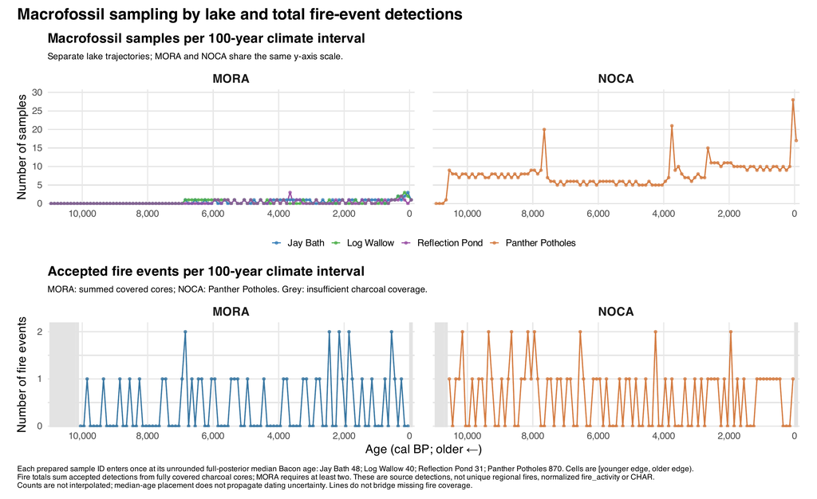

Inspect macrofossil sampling and accepted fire detections on native 100-year climate cells before CCA. — PDF page 1

## CCA calibration and geometry

One pooled legacy CCA relates composition to the four climate variables, using the same matched plots used in both-date comparisons (330 MORA and 277 NOCA). This matched calibration was selected on 2026-10-08; the former fit used 619 eligible legacy plots. The ≥20 species-selection rule and 14 taxa are unchanged. Observed **weighted-average (WA)** scores describe composition; predicted **linear-combination (LC)** scores describe the position expected from climate. Modern resurveys and paleo samples enter the existing ordination without recalibrating it.

| Fitted model quantity | Value |
| --- | --- |
| Legacy calibration plots | 607 |
| Retained taxa | 14 |
| Minimum occupancy in one site × period | 20 |
| CCA score scaling | Site scaling (1) |
| Hill scaling | Off |
| Climate variables | MSpT;MWT;SP;WP |
| Total inertia | 3.465 |
| Climate-constrained inertia | 0.531 |
| Constrained inertia (%) | 15.33 |
| Modern plots and paleo samples before eligibility | 1625 |
| Eligible modern pairs and paleo samples | 1538 |

Full CCA summary table.

| Site | Period | Prepared climate samples | Calibrated | Positioned projection |
| --- | --- | --- | --- | --- |
| MORA | paleo | 119 | — | 119 |
| MORA | past | 331 | 330 | — |
| MORA | present | 331 | — | 330 |
| NOCA | paleo | 870 | — | 812 |
| NOCA | past | 305 | 277 | — |
| NOCA | present | 305 | — | 277 |

Full CCA counts table.

CCA1–CCA2 and site scaling (1), with Hill scaling off, define all distances and angles. Display arrow multipliers do not enter calculations. Binary presence still carries CCA’s row and taxon weighting. The displayed axes represent only part of total community inertia, and correlated climate variables prevent adding their marginal contributions as independent shares. Projections are descriptive scores rather than independently validated forecasts.

### Compare scaling 1 and 2 of the same fitted CCA

Site scaling (1), Hill off and CCA1–CCA2 define the primary geometry. Unequal rescaling of axes changes distances and angles; display arrow multipliers are excluded from the calculations.

Script: test_cca_scaling_comparison.R. Complete PDF (1 page).

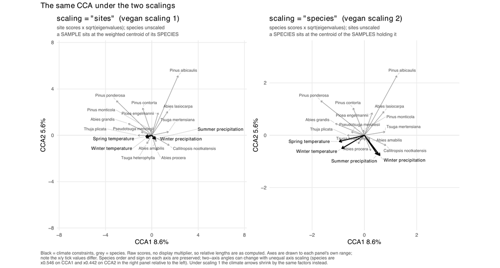

Compare scaling 1 and 2 of the same fitted CCA. — PDF page 1

### CCA model, contributions and tests

The model below is fitted to the **607 matched legacy plots and 14 retained tree species**. Species values are binary presence, combining adults and regeneration. The climate rows use those same plots in the same order. `MSpT` is spring temperature, `MWT` winter temperature, `SP` summer precipitation and `WP` winter precipitation. The fitting and resurvey-projection lines are copied from 04_cca_model.R, with the current scaling settings shown explicitly.

The calibration reference bundle preserves the fitted CCA, calibration matrices and identities, species and climate scores, scaling, prepared endpoints and provenance for future work.

```r
# Current settings; presence and climate tables are prepared above in 04_cca_model.R.
CCA_VARIABLES = c("MSpT", "MWT", "SP", "WP")
cca_scaling = "sites"
cca_hill = FALSE

# Matched legacy observations used to calibrate the CCA.
species_past_final = species_past[present_pairs, keep_species, drop = FALSE]
env_past_final = env_past[present_pairs, CCA_VARIABLES, drop = FALSE]

cca_formula = reformulate(CCA_VARIABLES, response = "species_past_final")
reference_path=here('output/cca_calibration_reference.rds')
if(file.exists(reference_path) && count.thr==CCA_COUNT_THRESHOLD && !length(extra_exclude) && !nzchar(cca_suffix)) {
  frozen=readRDS(reference_path)
  if(!isTRUE(all.equal(species_past_final,frozen$legacy_species,tolerance=0)) ||
     !isTRUE(all.equal(env_past_final,frozen$legacy_climate,tolerance=0)) ||
     !identical(keep_species,frozen$retained_species))
    stop('Fixed CCA calibration inputs changed; do not recalibrate during reconstruction migration')
  cca_model=frozen$model
} else cca_model=cca(cca_formula,data=env_past_final)

# Resurvey positions: climate-predicted (LC) and observed (WA).
predicted_present = predict(cca_model, newdata = env_present_final, type = "lc", scaling = cca_scaling, hill = cca_hill)
projected_present = predict(cca_model, newdata = species_present_final,
                            type = "wa", scaling = cca_scaling, hill = cca_hill)
```

**Fitted model output.** Inertia measures variation in community composition; the constrained part is the variation explained by these climate variables.

```
Call: cca(formula = species_past_final ~ MSpT + MWT + SP + WP, data =
env_past_final)

              Inertia Proportion Rank
Total          3.4648     1.0000
Constrained    0.5310     0.1533    4
Unconstrained  2.9338     0.8467   13

Inertia is scaled Chi-square

Eigenvalues for constrained axes:
   CCA1    CCA2    CCA3    CCA4
0.29766 0.19574 0.03152 0.00606

Eigenvalues for unconstrained axes:
   CA1    CA2    CA3    CA4    CA5    CA6    CA7    CA8    CA9   CA10   CA11
0.4902 0.3697 0.3563 0.3219 0.2565 0.2345 0.2029 0.1781 0.1375 0.1253 0.1153
  CA12   CA13
0.0993 0.0462
```

| Axis | Eigenvalue | % total inertia | % constrained inertia |
| --- | --- | --- | --- |
| CCA1 | 0.2977 | 8.591 | 56.06 |
| CCA2 | 0.1957 | 5.649 | 36.86 |
| CCA3 | 0.03152 | 0.9098 | 5.937 |
| CCA4 | 0.006062 | 0.175 | 1.142 |

Full CCA axes table.

**Permutation ANOVA.** The overall test assesses the four climate variables together. Axis tests assess each axis after accounting for preceding axes. All reported tests use **9,999 permutations**, with seed `20261008`. Unrestricted permutations shuffle plots across the whole calibration set; within-park permutations shuffle plots within MORA and NOCA separately. Neither design accounts for finer spatial dependence among plots. These are tests of association, rather than predictive validation. See the [vegan ANOVA methods](https://vegandevs.github.io/vegan/reference/anova.cca.html).

| Model / axis | df | Pseudo-F | p: unrestricted | p: within parks |
| --- | --- | --- | --- | --- |
| Whole model | 4 | 27.24 | 0.0001 | 0.0001 |
| CCA1 | 1 | 61.08 | 0.0001 | 0.0001 |
| CCA2 | 1 | 40.35 | 0.0001 | 0.0001 |
| CCA3 | 1 | 6.536 | 0.0001 | 0.0001 |
| CCA4 | 1 | 1.262 | 0.1712 | 0.1176 |

Full CCA anova table.

CCA1, CCA2 and CCA3 meet p < 0.05 when plots are shuffled within parks. CCA4 does not meet that threshold.

Complete ANOVA output includes residual degrees of freedom and all overall, axis and climate-variable tests. These calculations are reproduced by the reporting functions.

**Species contributions.** Each percentage is a species’ contribution to the total climate-explained inertia, across all four constrained axes. These contributions sum to 100% and determine the species arrow and annotation colors in Figure 3A. The score columns describe position on CCA1–CCA2; distance from the origin is a different quantity from contribution. See [vegan’s inertia decomposition](https://vegandevs.github.io/vegan/reference/goodness.cca.html).

| Species | Legacy plots | % climate-explained inertia | CCA1 score | CCA2 score |
| --- | --- | --- | --- | --- |
| Abies lasiocarpa | 92 | 12.37 | 1.376 | 2.049 |
| Pinus albicaulis | 18 | 11.74 | 2.274 | 5.141 |
| Tsuga mertensiana | 177 | 11.73 | 1.443 | 0.2977 |
| Callitropsis nootkatensis | 142 | 11.2 | 1.507 | -0.8713 |
| Pinus ponderosa | 22 | 9.647 | -3.055 | 2.979 |
| Thuja plicata | 205 | 9.629 | -1.194 | -0.007594 |
| Pseudotsuga menziesii | 332 | 8.46 | -0.9106 | 0.2949 |
| Tsuga heterophylla | 369 | 5.792 | -0.4345 | -0.7207 |
| Abies procera | 68 | 4.753 | 0.4455 | -1.324 |
| Pinus contorta | 33 | 4.187 | -0.7881 | 2.347 |
| Abies amabilis | 402 | 3.868 | 0.3899 | -0.5322 |
| Picea engelmannii | 36 | 2.885 | 0.5463 | 1.938 |
| Abies grandis | 19 | 2.568 | -2.027 | 1.011 |
| Pinus monticola | 70 | 1.173 | -0.06523 | 0.4517 |

Full CCA species contributions table.

**Climate contributions and tests.** Each percentage is the inertia lost when that variable is removed while the other three remain, divided by the full model’s climate-explained inertia. These are the unique effects shown in Figure 3; they do not sum to 100% because the predictors are correlated. Their tests use `anova(..., by = "margin")`. VIF describes predictor overlap: larger values mean stronger collinearity, limiting separate interpretation of climate variables.

| Climate variable | Unique % climate-explained inertia | VIF | Pseudo-F | p: unrestricted | p: within parks |
| --- | --- | --- | --- | --- | --- |
| Spring temperature | 7.094 | 29.5 | 7.729 | 0.0001 | 0.9646 |
| Winter temperature | 9.042 | 26.35 | 9.852 | 0.0001 | 0.9303 |
| Summer precipitation | 2.269 | 5.2 | 2.473 | 0.0032 | 0.001 |
| Winter precipitation | 3.617 | 6.695 | 3.94 | 0.0001 | 0.0001 |

Full CCA climate contributions table.

Spring temperature and winter temperature meet p < 0.05 with unrestricted permutations, but do not meet that threshold when plots are shuffled within parks. Summer precipitation and winter precipitation meet p < 0.05 under both permutation designs.

The existing tracking calculations use CCA1–CCA2. These tests describe the fitted model; they do not change the selected axes or the analysis settings.

## Climate eras and high-fire periods

Climate eras are defined independently of vegetation, fire and literature. Signed 1,000-year changes are divided by legacy-calibration standard deviations; MORA lakes are averaged first, then MORA and NOCA receive equal regional weight. A variable qualifies at 50% of its own maximum absolute regional median, with at least eight of ten offsets supporting its direction. Any qualifying variable marks climate change; adjacent cells merge into eras. The unsigned four-variable composite provides context, rather than defining a boundary. Complete offset support spans 9.6–1.3 ka.

| Era | Class | Older cal BP | Younger cal BP | Duration years |
| --- | --- | --- | --- | --- |
| CC1 | climate change | 9600 | 7200 | 2400 |
| S1 | relative stability | 7200 | 6800 | 400 |
| CC2 | climate change | 6800 | 6200 | 600 |
| S2 | relative stability | 6200 | 5400 | 800 |
| CC3 | climate change | 5400 | 4900 | 500 |
| S3 | relative stability | 4900 | 2200 | 2700 |
| CC4 | climate change | 2200 | 1700 | 500 |
| S4 | relative stability | 1700 | 1300 | 400 |

Full era catalog table.

High-fire periods are defined independently from centered 1,000-year event frequencies. Each core is normalized by its own maximum; MORA averages covered cores equally and requires at least two. A site’s frequency must exceed its median plus 1.4826 × MAD. Above-threshold periods are retained without bridging coverage gaps. Five MORA and six NOCA high-fire periods result. These categories use fixed median event chronologies, without propagating event-timing uncertainty.

### Expose signed changes, phase support, and era construction

Any qualifying variable creates a climate-change cell. Only adjacent cells merge; the unsigned composite is context.

Script: 05_holocene_climate_fire_eras.R. Complete PDF (1 page).

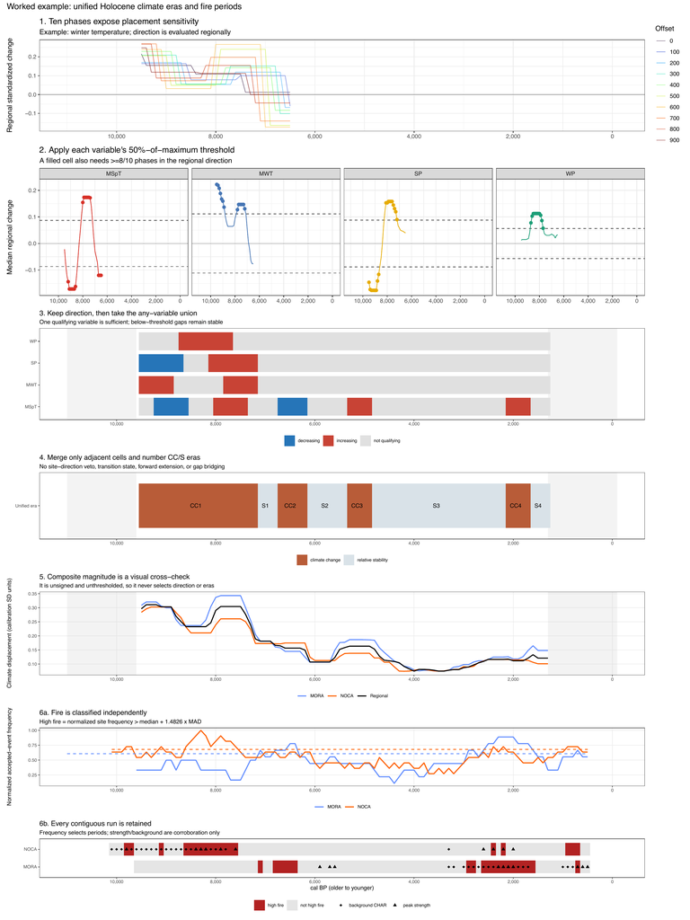

Expose signed changes, phase support, and era construction. — PDF page 1

### Work through centered event frequencies at 2,300 cal BP

Within-core normalization and site-specific robust thresholds yield MORA high fire and NOCA no high fire for the worked date.

Script: 06_fire_method_worked_example.R. Complete PDF (1 page).

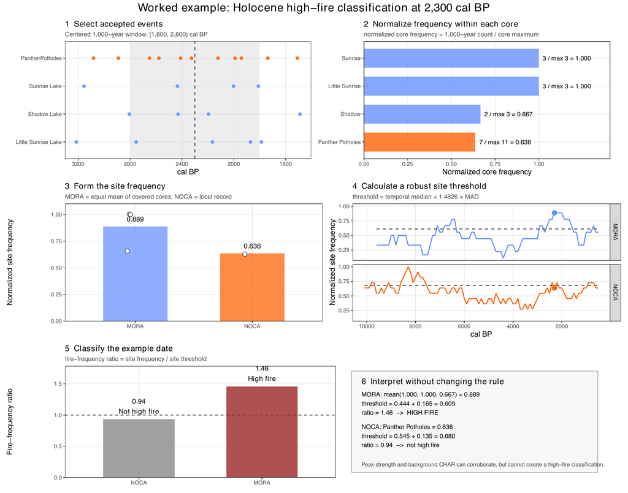

Work through centered event frequencies at 2,300 cal BP. — PDF page 1

## Tracking calculations

One primary reconstructed series is built for each lake. Original samples are projected through the fixed CCA before sample WA coordinates are averaged within their own native CHELSA cells, `[lower, upper)`. Occupied cell centers currently end in 50 cal BP. Consecutive occupied centuries are connected, including gaps; vegetation is never interpolated. Both endpoint climate records belong to that lake. All Holocene rates use the actual elapsed time, `age_hi - age_lo`, and response validity is handled independently.

Primary support counts describe actual endpoint samples. Chronology occupancy is diagnostic, with no authorized occupancy or joint-support exclusion threshold. The physical climate-rate index uses changes in MSpT, MWT, SP and WP divided by their fixed pooled legacy SDs, then combined by Euclidean norm and multiplied by 100/elapsed years. It is separate from LC movement.

Fire exposure counts accepted events over `[age_lo, age_hi)`. Each fully covered core contributes `events × 100 / elapsed years`. MORA averages at least two fully covered regional cores equally; NOCA requires complete Panther Potholes coverage. Covered zeros remain zero and inadequate coverage remains NA. The unit is events per century per eligible core. This differs from the unchanged normalized 1,000-year fire measure used in descriptive climate/fire-period comparisons.

| Lake | Occupied centuries | Transitions | Gaps over 100 years | Median duration (years) | Missing fire exposure |
| --- | --- | --- | --- | --- | --- |
| JayBath | 44 | 43 | 15 | 100 | 0 |
| LogWallow | 35 | 34 | 15 | 100 | 0 |
| ReflectionPond | 28 | 27 | 20 | 200 | 0 |
| PantherPotholes | 108 | 107 | 0 | 100 | 1 |

Full lake support table.

**Endpoint geometry and lag/turnover rates.**

```r
coords = c("o1", "o2", "o1_2", "o2_2", "p1", "p2", "p1_2", "p2_2")
ox = x$o1_2-x$o1; oy = x$o2_2-x$o2
px = x$p1_2-x$p1; py = x$p2_2-x$p2
a = sqrt(ox^2+oy^2); b = sqrt(px^2+py^2)
x$finite_endpoints = rowSums(!is.finite(as.matrix(x[coords]))) == 0L
observed_direction = x$finite_endpoints & is.finite(a) & a > epsilon
predicted_direction = x$finite_endpoints & is.finite(b) & b > epsilon
x$observed_vegetation_displacement = a
x$predicted_vegetation_displacement = b
x$observed_turnover_rate = a/x$vegetation_dt_years*100
x$predicted_vegetation_change_rate = b/x$climate_dt_years*100
x$lag_t1 = sqrt((x$o1-x$p1)^2+(x$o2-x$p2)^2)
x$lag_t2 = sqrt((x$o1_2-x$p1_2)^2+(x$o2_2-x$p2_2)^2)
x$change_in_lag = x$lag_t2-x$lag_t1
x$lag_rate_per_century = x$change_in_lag/x$climate_dt_years*100
```

**Tracking ratios and turnover angle.**

```r
x$magnitude_tracking_ratio = ifelse(predicted_direction, a/b, NA_real_)
x$rate_tracking_ratio = ifelse(predicted_direction,
  x$observed_turnover_rate/x$predicted_vegetation_change_rate, NA_real_)
x$angle_degrees = acos(safe_cosine_2d(ox, oy, px, py, epsilon))*180/pi
```

**Guarded cosine used internally for the angle.**

```r
a = sqrt(ax^2 + ay^2); b = sqrt(bx^2 + by^2)
ok = is.finite(a) & is.finite(b) & a > epsilon & b > epsilon
result = rep(NA_real_, n)
result[ok] = pmax(-1, pmin(1, (ax[ok]*bx[ok] + ay[ok]*by[ok])/(a[ok]*b[ok])))
```

**Pace and direction counterfactual effects.**

```r
# Only divide by a direction's magnitude when that direction is defined.
x$pace_corrected_CCA1 = x$pace_corrected_CCA2 = rep(NA_real_, nrow(x))
x$direction_corrected_CCA1 = x$direction_corrected_CCA2 = rep(NA_real_, nrow(x))
i = observed_direction
x$pace_corrected_CCA1[i] = x$o1[i]+b[i]*ox[i]/a[i]
x$pace_corrected_CCA2[i] = x$o2[i]+b[i]*oy[i]/a[i]
i = predicted_direction
x$direction_corrected_CCA1[i] = x$o1[i]+a[i]*px[i]/b[i]
x$direction_corrected_CCA2[i] = x$o2[i]+a[i]*py[i]/b[i]
x$lag_t2_pace_corrected = sqrt((x$pace_corrected_CCA1-x$p1_2)^2+
  (x$pace_corrected_CCA2-x$p2_2)^2)
x$lag_t2_direction_corrected = sqrt((x$direction_corrected_CCA1-x$p1_2)^2+
  (x$direction_corrected_CCA2-x$p2_2)^2)
x$pace_effect_on_lag = x$lag_t2-x$lag_t2_pace_corrected
x$direction_effect_on_lag = x$lag_t2-x$lag_t2_direction_corrected
x$pace_effect_on_lag_per_century = x$pace_effect_on_lag/x$climate_dt_years*100
x$direction_effect_on_lag_per_century = x$direction_effect_on_lag/x$climate_dt_years*100
```

**Auxiliary corrected lag-change rates retained for geometric auditing (not fitted responses).**

```r
x$pace_corrected_lag_rate_per_century = ifelse(x$pace_counterfactual_valid,
  (x$lag_t2_pace_corrected-x$lag_t1)*100/x$climate_dt_years, NA_real_)
x$direction_corrected_lag_rate_per_century = ifelse(x$direction_counterfactual_valid,
  (x$lag_t2_direction_corrected-x$lag_t1)*100/x$climate_dt_years, NA_real_)
```

**Physical seasonal climate changes and standardized rate.**

```r
z_change_cols = character(0)
z_rate_cols = character(0)
for (v in vars) {
  s = scaling$sd[match(v, scaling$variable)]
  delta = x[[paste0(v, "_2")]] - x[[v]]
  x[[paste0(v, "_change")]] = delta
  x[[paste0(v, "_rate_per_century")]] = delta / x$climate_dt_years * 100
  x[[paste0(v, "_z_change")]] = delta / s
  x[[paste0(v, "_z_rate_per_century")]] = delta / s / x$climate_dt_years * 100
  z_change_cols = c(z_change_cols, paste0(v, "_z_change"))
  z_rate_cols = c(z_rate_cols, paste0(v, "_z_rate_per_century"))
}
x$standardized_climate_displacement = sqrt(rowSums(x[z_change_cols]^2))
x$standardized_climate_change_rate = sqrt(rowSums(x[z_rate_cols]^2))
```

| Plot | Presence removed from pooled resurvey |
| --- | --- |
| LONG-356 | Thuja plicata |
| LOWE-045 | Acer circinatum |
| RAMP-505 | Abies amabilis |
| RAMP-505 | Abies grandis |
| RAMP-505 | Pinus monticola |
| RAMP-505 | Thuja plicata |
| SMO-364 | Tsuga mertensiana |
| SUNS-046 | Thuja plicata |
| WHIT-273 | Abies lasiocarpa |
| WHIT-273 | Alnus rubra |
| WHIT-273 | Picea sitchensis |
| WHIT-307 | Tsuga mertensiana |

Full latest visit composition effects table.

| Site | Quantity | Changed plots | Before median | After median |
| --- | --- | --- | --- | --- |
| MORA | Adult resurvey year | 50 | 2015 | 2015 |
| MORA | Climate interval (years) | 319 | 30.5 | 28.5 |
| MORA | Observed displacement (CCA units) | 6 | 0.3168 | 0.3182 |
| MORA | Predicted displacement (CCA units) | 330 | 0.4074 | 0.3809 |
| MORA | Rate tracking ratio | 254 | 0.6559 | 0.6124 |
| MORA | Change in lag (CCA units) | 330 | 0.1644 | 0.1189 |
| MORA | Lag rate (CCA units/century) | 330 | 0.5389 | 0.4171 |
| NOCA | Adult resurvey year | 0 | 2015 | 2015 |
| NOCA | Climate interval (years) | 50 | 28.5 | 28.5 |
| NOCA | Observed displacement (CCA units) | 0 | 0.5205 | 0.5205 |
| NOCA | Predicted displacement (CCA units) | 50 | 0.2114 | 0.204 |
| NOCA | Rate tracking ratio | 40 | 2.263 | 2.436 |
| NOCA | Change in lag (CCA units) | 50 | -0.002621 | 0.005775 |
| NOCA | Lag rate (CCA units/century) | 50 | -0.009197 | 0.021 |

Full survey decision effects table.

## Community trajectories

Figure 3 places **A, the species/climate biplot**, beside **B, the trajectory projections** in a wider, two-panel layout. Panel A labels all 14 taxa, including those near the origin. Species names give occurrence percentages across the 607 calibration plots; arrow and annotation colors encode each species’ share of total constrained inertia. Climate arrow and annotation colors encode unique marginal percentages of that same denominator. A blue–purple–orange gradient uses the manuscript park colors as its endpoints; exact inertia percentages remain in the tables rather than beside the arrows. Species shares sum to 100%; climate unique effects do not partition the total because predictors share explanatory variation. The tables above retain all exact values from the former contribution bars. Climate arrows retain their common display multiplier; arrow length is not the inertia color statistic.

Panel B is zoomed to the trajectories, with the calibration cloud cropped only for display. Observed paths retain park colors; predicted paths and annotations use lighter, fully opaque versions of those colors. The observed/predicted arrow legend remains dark/light grey. Jointly placed direct labels and time annotations use leader lines to reduce collisions.

Holocene period centroids first average primary occupied centuries within lake/period, then average available lakes equally. Period membership uses the unchanged CC/S catalog boundaries. Missing lake/period coverage is not manufactured. The fitted species/climate panels remain based on the unchanged CCA.

| Site | Survey | Same paired plots | Observed CCA1 | Observed CCA2 | Predicted CCA1 | Predicted CCA2 |
| --- | --- | --- | --- | --- | --- | --- |
| MORA | legacy | 330 | 0.01916 | -0.2931 | 0.02739 | -0.2841 |
| MORA | resurvey | 330 | 0.007418 | -0.3313 | -0.3602 | -0.1502 |
| NOCA | legacy | 277 | -0.1207 | 0.4995 | -0.1007 | 0.455 |
| NOCA | resurvey | 277 | -0.1448 | 0.3547 | -0.24 | 0.4876 |

Full modern centroids table.

| Site | Era | Positioned dates | Observed CCA1 | Observed CCA2 | Predicted CCA1 | Predicted CCA2 |
| --- | --- | --- | --- | --- | --- | --- |
| MORA | S1 | 2 | 0.2127 | 0.4883 | -0.03114 | -0.8229 |
| MORA | CC2 | 8 | 0.2847 | 0.5589 | 0.1101 | -0.8018 |
| MORA | S2 | 13 | 0.5182 | 0.5153 | 0.1399 | -0.7939 |
| MORA | CC3 | 6 | 0.5117 | 0.5778 | 0.1425 | -0.7903 |
| MORA | S3 | 35 | 0.7423 | 0.2939 | 0.07991 | -0.8344 |
| MORA | CC4 | 7 | 0.7548 | -0.2904 | 0.1232 | -0.8378 |
| MORA | S4 | 5 | 0.7197 | 0.006679 | 0.05344 | -0.9019 |
| NOCA | CC1 | 24 | -0.1832 | 1.375 | -0.3386 | 0.3744 |
| NOCA | S1 | 4 | -0.1259 | 0.8604 | -0.4065 | 0.2482 |
| NOCA | CC2 | 6 | -0.2318 | 1.012 | -0.3466 | 0.2963 |
| NOCA | S2 | 8 | -0.01874 | 0.9342 | -0.3134 | 0.2727 |
| NOCA | CC3 | 5 | 0.02032 | 0.7776 | -0.3194 | 0.19 |
| NOCA | S3 | 27 | -0.2153 | 0.6146 | -0.3436 | 0.207 |
| NOCA | CC4 | 5 | -0.2352 | 0.4099 | -0.328 | 0.3002 |
| NOCA | S4 | 4 | -0.3268 | 0.06199 | -0.3654 | 0.2114 |

Full era centroids table.

### Figure 3. Observed and climate-predicted community trajectories

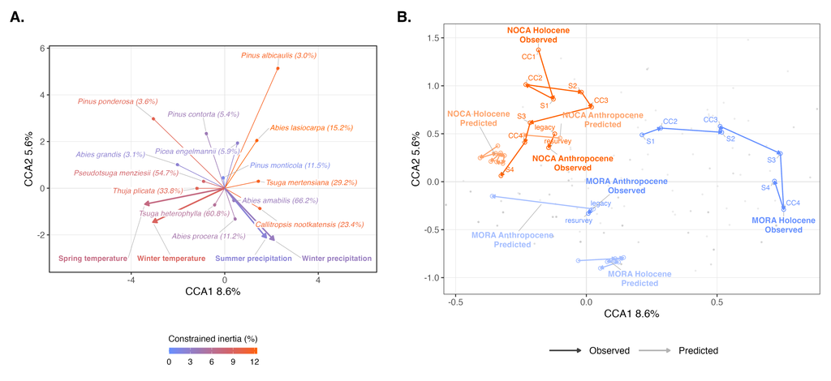

Figure 3. fig cca trajectories

Full PDF · Figure script.

## Tracking example and actual-transition displays

The worked example uses one primary actual transition. Temporal displays show actual transition midpoints and spans with matching climate and fire exposure. Both tracking ratios remain in the tables; their identical Holocene values need only one display. Modern fire activity is unavailable as a continuous charcoal measure; original binary burned assignments remain available.

### Work through WA/LC movement, lag, ratio, and angle

One actual primary Panther Potholes transition shows WA/LC endpoints, counterfactuals, seven responses, endpoint samples and actual elapsed time. Corrections are nonadditive.

Script: 09_tracking_example_and_visualizations.R. Complete PDF (1 page).

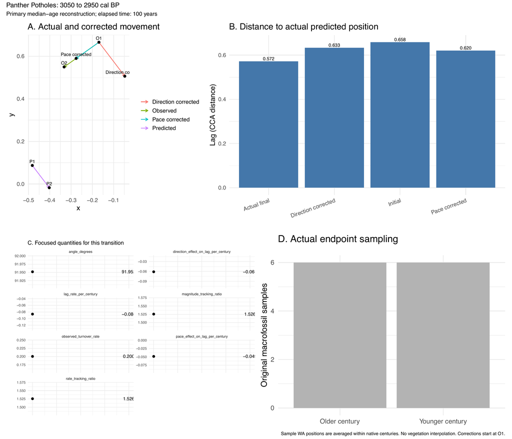

Work through WA/LC movement, lag, ratio, and angle. — PDF page 1

### Compare tracking responses, climate and fire under established regional climate-period bands, with Anthropocene boxplots

Actual primary transition estimates, without vegetation interpolation or bin offsets. Fire is events per century per eligible core. **Primary reconstruction; conditional inference**.

Script: 09_tracking_example_and_visualizations.R. Complete PDF (1 page).

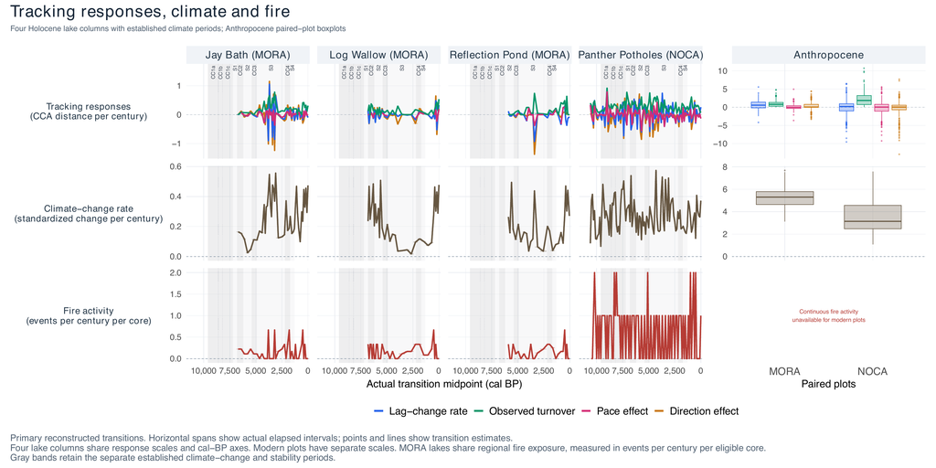

Compare tracking responses, climate and fire under established regional climate-period bands, with Anthropocene boxplots. — PDF page 1

### Compare magnitude tracking ratio, angle, climate and fire under the same regional climate-period bands, one variable per row

Actual primary transition estimates, without vegetation interpolation or bin offsets. Fire is events per century per eligible core. **Primary reconstruction; conditional inference**.

Script: 09_tracking_example_and_visualizations.R. Complete PDF (1 page).

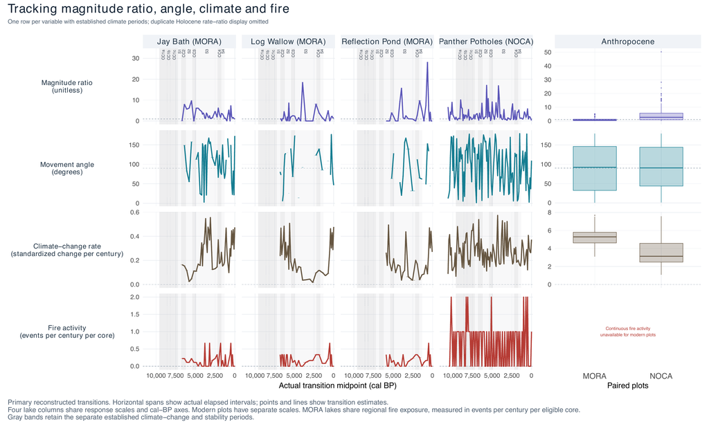

Compare magnitude tracking ratio, angle, climate and fire under the same regional climate-period bands, one variable per row. — PDF page 1

| Constraint | Units | Holocene regional signed maximum | Peak cal BP | MORA modern median | NOCA modern median |
| --- | --- | --- | --- | --- | --- |
| Spring temperature | deg C / century | 0.04175 | 7500 | 1.288 | 0.7691 |
| Winter temperature | deg C / century | 0.05504 | 9500 | 3.271 | 1.359 |
| Summer precipitation | mm / century | -1.087 | 8900 | -142.6 | 103.6 |
| Winter precipitation | mm / century | 2.338 | 8100 | -937.2 | -411.2 |

Full raw climate rates table.

### Figure 2. Climate eras, climate rates and high-fire periods

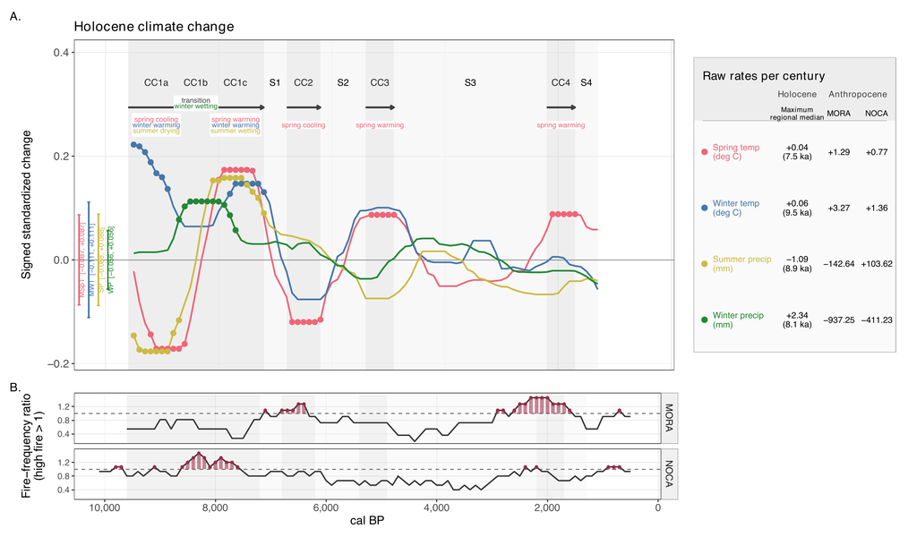

Figure 2. fig standardized climate change eras fire

Full PDF · Figure script.

## Primary models and residual covariance comparisons

Primary, Bacon sensitivity and lake-check results use separate folders. Metric-specific figures are consolidated into multipage PDFs by purpose, with one labeled response per page.

Primary, Bacon sensitivity and lake-check folder guide.

### Residual covariance comparison

Combined-era models use `estimate ~ era * site` and separate residual variances by era/site. Modern plots are singleton series. Applicable Holocene models compare independent residuals, neighboring-transition MA(1), and continuous-time AR(1). Transition indices are assigned before exclusions; gaps are not renumbered. Continuous-time correlation uses actual midpoints in centuries. Compare REML AIC only on identical rows and fixed effects. **MA(1) is the primary covariance for every model containing Holocene observations**, as explicitly retained by the user. Independent and CAR1 are comparison diagnostics only; AIC recommendations never replace MA(1). Failed fits and boundary/covariance warnings remain in the result tables. Modern-only models retain independent residuals.

```r
# Same fixed effects and rows; Independent/CAR1 are comparisons only.
correlation = NULL
correlation = nlme::corARMA(p = 0, q = 1, form = ~ time_index | series)
correlation = nlme::corCAR1(form = ~ time_centuries | series)
# Primary Holocene community and species explanatory models: MA(1).
correlation = nlme::corARMA(p = 0, q = 1, form = ~ time_index | series)
nlme::gls(estimate ~ site + climate_rate + fire_activity, data = d,
  correlation = correlation, weights = nlme::varIdent(form = ~ 1 | site),
  method = 'REML', na.action = na.fail)
# Anthropocene species and basic community model:
nlme::gls(estimate ~ site + burned, data = d,
  weights = nlme::varIdent(form = ~ 1 | site), method = 'REML')
# Extended Anthropocene COMMUNITY model only:
nlme::gls(estimate ~ site + elevation + climate_rate + burned, data = d,
  weights = nlme::varIdent(form = ~ 1 | site), method = 'REML')
```

### Compare independent, neighboring MA(1), and continuous-time AR(1) residual covariance on identical primary observations

One primary median-age reconstruction. MA(1) is primary for models containing Holocene observations; Independent and CAR1 are comparisons only. Confidence intervals are conditional on the reconstruction. **Primary reconstruction; conditional inference**.

Script: 12_tracking_era_models.R. Complete PDF (5 pages).

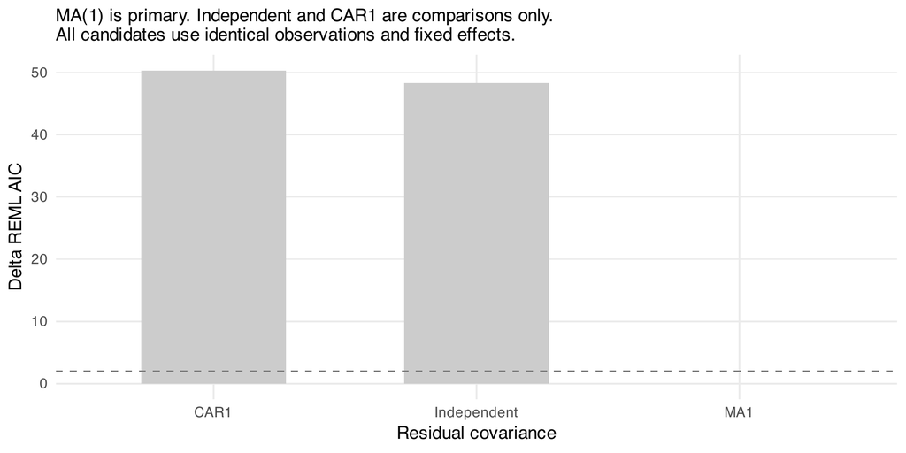

Compare independent, neighboring MA(1), and continuous-time AR(1) residual covariance on identical primary observations. — PDF page 1

### Selected-covariance fitted Holocene/Anthropocene group means and contrasts for the primary reconstruction

One primary median-age reconstruction. MA(1) is primary for models containing Holocene observations; Independent and CAR1 are comparisons only. Confidence intervals are conditional on the reconstruction. **Primary reconstruction; conditional inference**.

Script: 12_tracking_era_models.R. Complete PDF (5 pages).

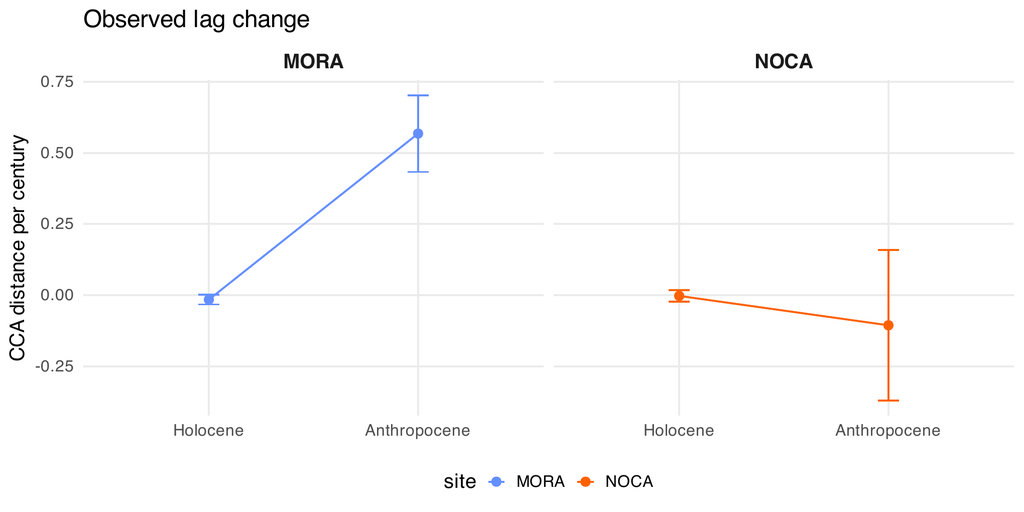

Selected-covariance fitted Holocene/Anthropocene group means and contrasts for the primary reconstruction. — PDF page 1

### Selected-covariance coefficients for the primary reconstruction

One primary median-age reconstruction. MA(1) is primary for models containing Holocene observations; Independent and CAR1 are comparisons only. Confidence intervals are conditional on the reconstruction. **Primary reconstruction; conditional inference**.

Script: 12_tracking_era_models.R. Complete PDF (5 pages).

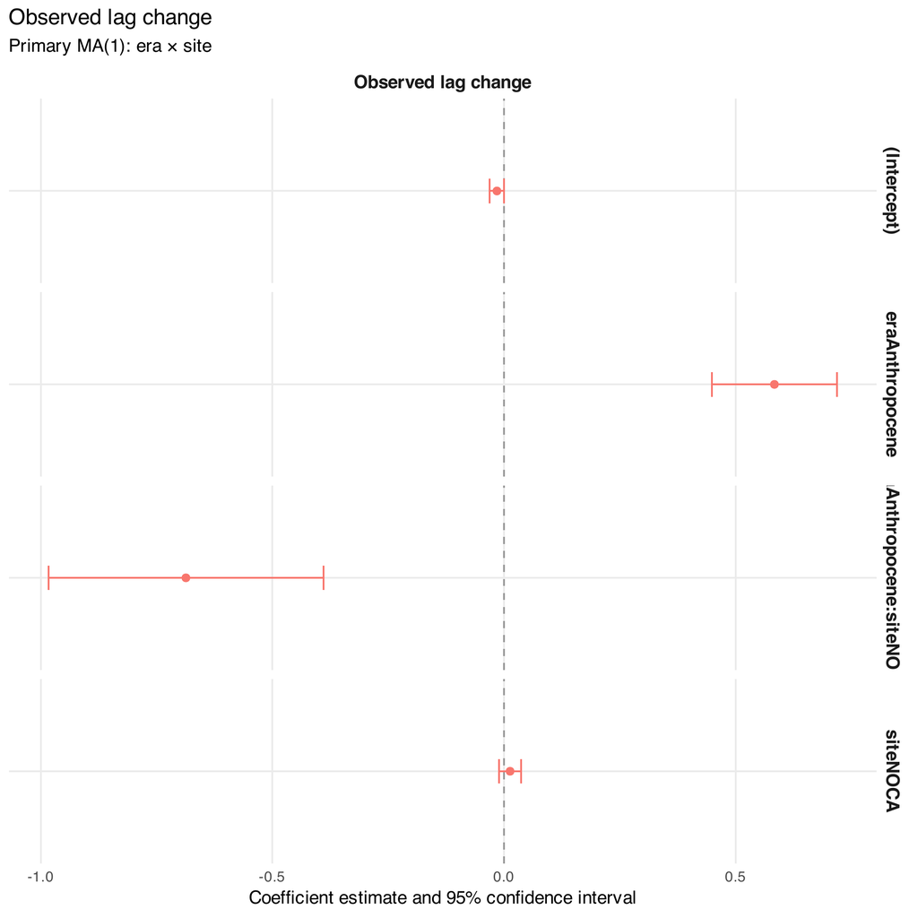

Selected-covariance coefficients for the primary reconstruction. — PDF page 1

### Selected-covariance Anthropocene-minus-Holocene contrasts for the primary reconstruction within each park

One primary median-age reconstruction. MA(1) is primary for models containing Holocene observations; Independent and CAR1 are comparisons only. Confidence intervals are conditional on the reconstruction. **Primary reconstruction; conditional inference**.

Script: 12_tracking_era_models.R. Complete PDF (5 pages).

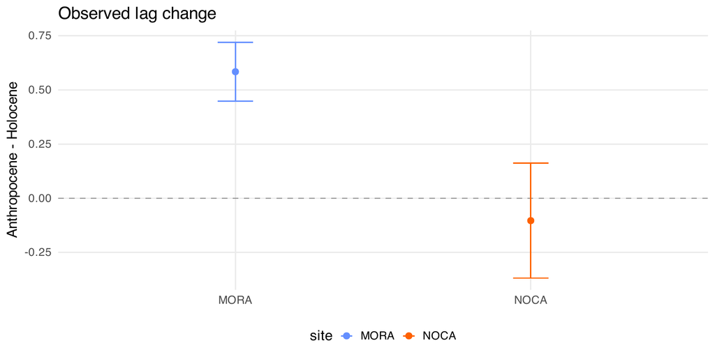

Selected-covariance Anthropocene-minus-Holocene contrasts for the primary reconstruction within each park. — PDF page 1

### Residual checks for the selected Selected-covariance for the primary reconstruction

One primary median-age reconstruction. MA(1) is primary for models containing Holocene observations; Independent and CAR1 are comparisons only. Confidence intervals are conditional on the reconstruction. **Primary reconstruction; conditional inference**.

Script: 12_tracking_era_models.R. Complete PDF (5 pages).

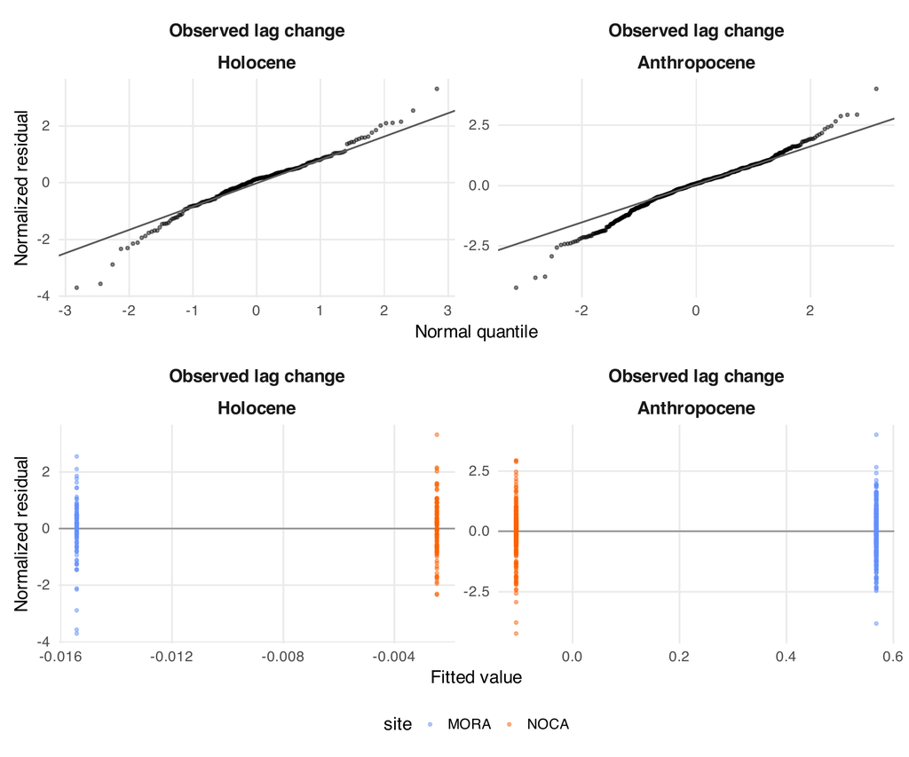

Residual checks for the selected Selected-covariance for the primary reconstruction. — PDF page 1

Complete primary results and covariance comparisons.

### Selected-covariance individual-lake coefficients for the primary reconstruction

Primary individual-lake comparison with modern plots in its park; the primary MA(1) covariance is reestimated. **Primary reconstruction; conditional inference**.

Script: 13_tracking_lake_sensitivity.R. Complete PDF (5 pages).

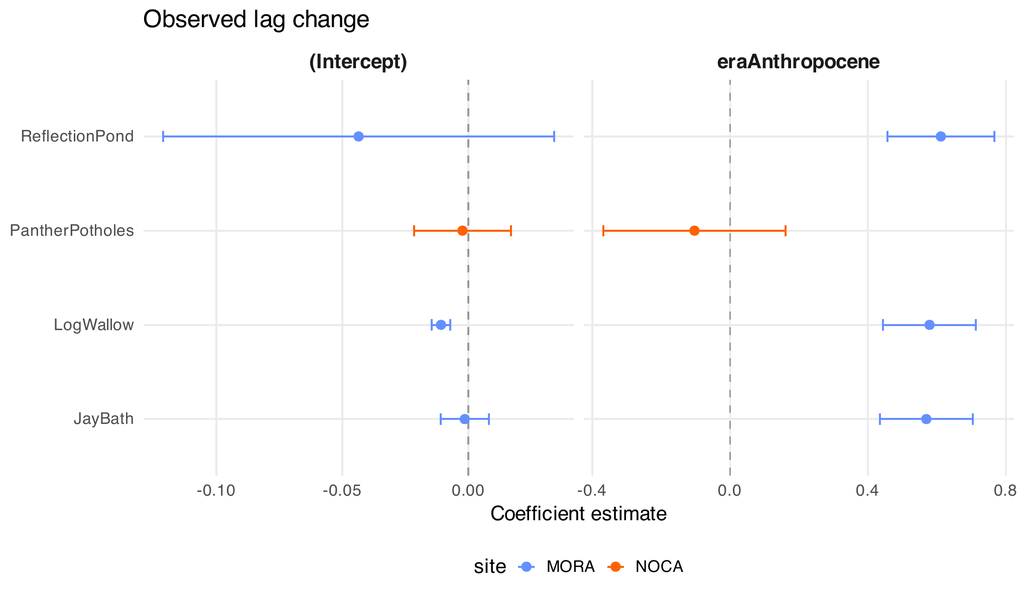

Selected-covariance individual-lake coefficients for the primary reconstruction. — PDF page 1

### Selected-covariance Anthropocene-minus-Holocene lake contrasts for the primary reconstruction

Primary individual-lake comparison with modern plots in its park; the primary MA(1) covariance is reestimated. **Primary reconstruction; conditional inference**.

Script: 13_tracking_lake_sensitivity.R. Complete PDF (5 pages).

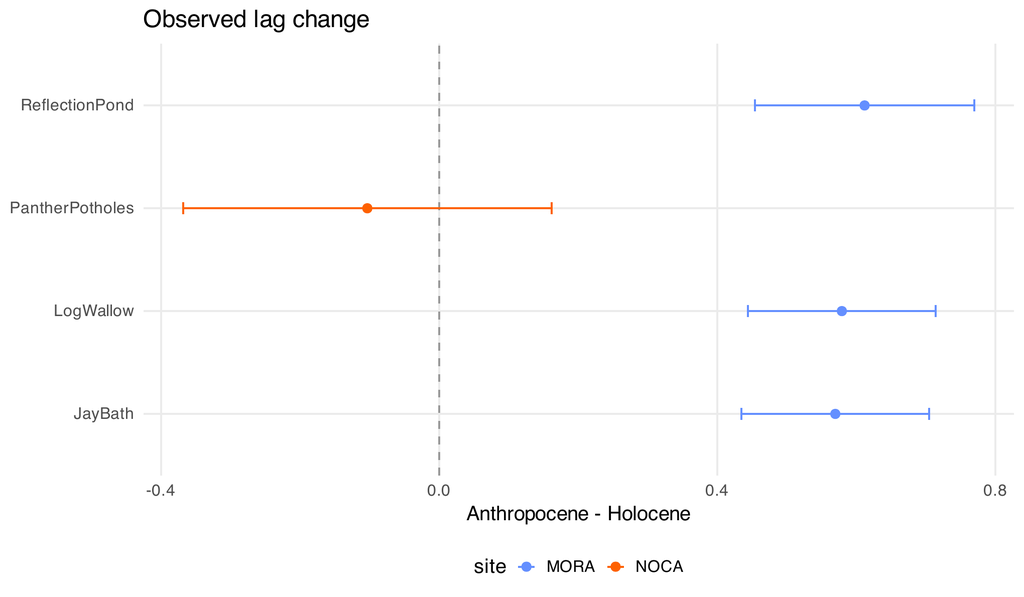

Selected-covariance Anthropocene-minus-Holocene lake contrasts for the primary reconstruction. — PDF page 1

Complete primary lake sensitivity results.

### Compare independent, neighboring MA(1), and continuous-time AR(1) residual covariance on identical primary observations

One primary median-age reconstruction. MA(1) is primary for models containing Holocene observations; Independent and CAR1 are comparisons only. Confidence intervals are conditional on the reconstruction. **Primary reconstruction; conditional inference**.

Script: 12_tracking_era_models.R. Complete PDF (5 pages).

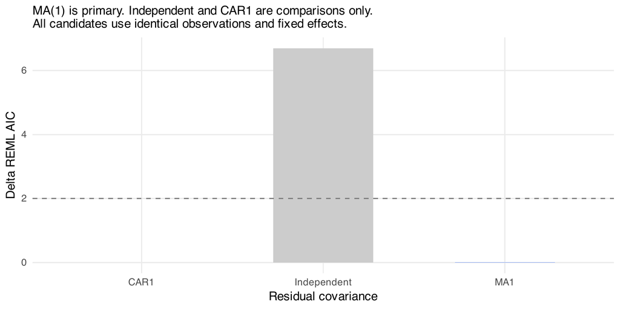

Compare independent, neighboring MA(1), and continuous-time AR(1) residual covariance on identical primary observations. — PDF page 2